# Table of Contents

# [Kaggle: Novel Corona Virus 2019 Dataset](https://www.kaggle.com/sudalairajkumar/novel-corona-virus-2019-dataset/)

- Dataset file is updated till 30th March

```python
import pandas as pd
import numpy as np

import matplotlib.pyplot as plt
%matplotlib inline

import warnings
warnings.filterwarnings(action='ignore')
```

### Basic Functions

- read_csv
- head
- rename
- shape
- columns
- info
- describe
- nunique & unique
- max, min, mean, agg

```python
covid19_df = pd.read_csv('../datasets/covid_19_data.csv', )
```

```python
covid19_df.head()
```

|  | SNo | ObservationDate | Province/State | Country/Region | Last Update | Confirmed | Deaths | Recovered |
| --- | --- | --- | --- | --- | --- | --- | --- | --- |
| 0 | 1 | 01/22/2020 | Anhui | Mainland China | 1/22/2020 17:00 | 1.0 | 0.0 | 0.0 |
| 1 | 2 | 01/22/2020 | Beijing | Mainland China | 1/22/2020 17:00 | 14.0 | 0.0 | 0.0 |
| 2 | 3 | 01/22/2020 | Chongqing | Mainland China | 1/22/2020 17:00 | 6.0 | 0.0 | 0.0 |
| 3 | 4 | 01/22/2020 | Fujian | Mainland China | 1/22/2020 17:00 | 1.0 | 0.0 | 0.0 |
| 4 | 5 | 01/22/2020 | Gansu | Mainland China | 1/22/2020 17:00 | 0.0 | 0.0 | 0.0 |

```python
covid19_df.rename(columns={'Province/State': 'State',
                           'Country/Region': 'Country'},
                  inplace=True)
print(covid19_df.shape)
print(covid19_df.columns)
```

```
(10358, 8)
Index(['SNo', 'ObservationDate', 'State', 'Country', 'Last Update',
       'Confirmed', 'Deaths', 'Recovered'],
      dtype='object')
```

```python
covid19_df.info()
```

```
<class 'pandas.core.frame.DataFrame'>
RangeIndex: 10358 entries, 0 to 10357
Data columns (total 8 columns):
 #   Column           Non-Null Count  Dtype
---  ------           --------------  -----
 0   SNo              10358 non-null  int64
 1   ObservationDate  10358 non-null  object
 2   State            5578 non-null   object
 3   Country          10358 non-null  object
 4   Last Update      10358 non-null  object
 5   Confirmed        10358 non-null  float64
 6   Deaths           10358 non-null  float64
 7   Recovered        10358 non-null  float64
dtypes: float64(3), int64(1), object(4)
memory usage: 647.5+ KB
```

```python
covid19_df.describe()
```

|  | SNo | Confirmed | Deaths | Recovered |
| --- | --- | --- | --- | --- |
| count | 10358.000000 | 10358.000000 | 10358.000000 | 10358.000000 |
| mean | 5179.500000 | 941.068160 | 37.830952 | 281.068836 |
| std | 2990.241378 | 6036.323228 | 371.916696 | 2972.773363 |
| min | 1.000000 | 0.000000 | 0.000000 | 0.000000 |
| 25% | 2590.250000 | 3.000000 | 0.000000 | 0.000000 |
| 50% | 5179.500000 | 29.000000 | 0.000000 | 0.000000 |
| 75% | 7768.750000 | 210.000000 | 2.000000 | 13.000000 |
| max | 10358.000000 | 101739.000000 | 11591.000000 | 62889.000000 |

**Question. How many Countries has been effected by Covid-19?**

```python
covid19_df['Country'].nunique()
```

```
213
```

**Question. Find out the Countries name that has been effected by Covid-19?**

```python
covid19_df['Country'].unique()[:20]
```

```
array(['Mainland China', 'Hong Kong', 'Macau', 'Taiwan', 'US', 'Japan',
       'Thailand', 'South Korea', 'Singapore', 'Philippines', 'Malaysia',
       'Vietnam', 'Australia', 'Mexico', 'Brazil', 'Colombia', 'France',
       'Nepal', 'Canada', 'Cambodia'], dtype=object)
```

**Questions. What is the Maximum value for Confirmed, Deaths, Recovered Colums?**

```python
covid19_df[['Confirmed', 'Deaths', 'Recovered']].max()
```

```
Confirmed    101739.0
Deaths        11591.0
Recovered     62889.0
dtype: float64
```

```python
# Using multiple aggregation functions together
covid19_df[['Confirmed', 'Deaths', 'Recovered']].agg(['max', 'min', 'mean'])
```

|  | Confirmed | Deaths | Recovered |
| --- | --- | --- | --- |
| max | 101739.00000 | 11591.000000 | 62889.000000 |
| min | 0.00000 | 0.000000 | 0.000000 |
| mean | 941.06816 | 37.830952 | 281.068836 |

### Removing Columns

```python
# Removing the column
print(covid19_df.drop('Last Update', axis=1).shape)
print(covid19_df.shape)
```

```
(10358, 7)
(10358, 8)
```

```python
covid19_df.drop('Last Update', axis=1, inplace=True)
covid19_df.shape
```

```
(10358, 7)
```

### Filtering

**Question. Find a row with Maximum confirmed cases?**

```python
covid19_df[covid19_df['Confirmed'] == covid19_df['Confirmed'].max()]
```

|  | SNo | ObservationDate | State | Country | Confirmed | Deaths | Recovered |
| --- | --- | --- | --- | --- | --- | --- | --- |
| 10125 | 10126 | 03/30/2020 | NaN | Italy | 101739.0 | 11591.0 | 14620.0 |

**Question. What is the latest numbers of cases in different states of US? Sort the results by Confirmed column in descending order**

```python
covid19_df[
    (covid19_df['ObservationDate'] == covid19_df['ObservationDate'].max()) &
    (covid19_df['Country'] == 'US')]\
    .sort_values('Confirmed', ascending=False)\
    .head()
```

|  | SNo | ObservationDate | State | Country | Confirmed | Deaths | Recovered |
| --- | --- | --- | --- | --- | --- | --- | --- |
| 10303 | 10304 | 03/30/2020 | New York | US | 66663.0 | 1218.0 | 0.0 |
| 10300 | 10301 | 03/30/2020 | New Jersey | US | 16636.0 | 198.0 | 0.0 |
| 10234 | 10235 | 03/30/2020 | California | US | 7138.0 | 146.0 | 0.0 |
| 10289 | 10290 | 03/30/2020 | Michigan | US | 6498.0 | 184.0 | 0.0 |
| 10287 | 10288 | 03/30/2020 | Massachusetts | US | 5752.0 | 56.0 | 0.0 |

**Question. What are the latest total number of Confirmed, Deaths & Recovered cases?**

```python
covid19_df[covid19_df['ObservationDate'] == covid19_df['ObservationDate'].max()]\
    [['Confirmed', 'Deaths', 'Recovered']]\
    .apply(np.sum)
```

```
Confirmed    782365.0
Deaths        37582.0
Recovered    164566.0
dtype: float64
```

### Grouping

**Question. Which are the top 10 countries(sorted by Confirmed cases) with Confirmed, Deaths & Recovered numbers?**

```python
covid19_df[covid19_df['ObservationDate'] == covid19_df['ObservationDate'].max()]\
    .groupby('Country')\
    [['Confirmed', 'Deaths', 'Recovered']]\
    .sum()\
    .sort_values('Confirmed', ascending=False)\
    .head(10)
```

| Country | Confirmed | Deaths | Recovered |
| --- | --- | --- | --- |
| US | 161807.0 | 2978.0 | 5644.0 |
| Italy | 101739.0 | 11591.0 | 14620.0 |
| Spain | 87956.0 | 7716.0 | 16780.0 |
| Mainland China | 81478.0 | 3304.0 | 75790.0 |
| Germany | 66885.0 | 645.0 | 13500.0 |
| France | 45170.0 | 3030.0 | 7964.0 |
| Iran | 41495.0 | 2757.0 | 13911.0 |
| UK | 22453.0 | 1411.0 | 171.0 |
| Switzerland | 15922.0 | 359.0 | 1823.0 |
| Belgium | 11899.0 | 513.0 | 1527.0 |

```python
# Using nlargest instead of sort() & head()
covid19_df[covid19_df['ObservationDate'] == covid19_df['ObservationDate'].max()]\
    .groupby('Country')\
    [['Confirmed', 'Deaths', 'Recovered']]\
    .sum()\
    .nlargest(10, 'Confirmed')
```

| Country | Confirmed | Deaths | Recovered |
| --- | --- | --- | --- |
| US | 161807.0 | 2978.0 | 5644.0 |
| Italy | 101739.0 | 11591.0 | 14620.0 |
| Spain | 87956.0 | 7716.0 | 16780.0 |
| Mainland China | 81478.0 | 3304.0 | 75790.0 |
| Germany | 66885.0 | 645.0 | 13500.0 |
| France | 45170.0 | 3030.0 | 7964.0 |
| Iran | 41495.0 | 2757.0 | 13911.0 |
| UK | 22453.0 | 1411.0 | 171.0 |
| Switzerland | 15922.0 | 359.0 | 1823.0 |
| Belgium | 11899.0 | 513.0 | 1527.0 |

```python
# Result without specifying the Columns in the output dataframe
covid19_df[covid19_df['ObservationDate'] == covid19_df['ObservationDate'].max()]\
    .groupby('Country')\
    .sum()\
    .nlargest(10, 'Confirmed')
```

| Country | SNo | Confirmed | Deaths | Recovered |
| --- | --- | --- | --- | --- |
| US | 607192 | 161807.0 | 2978.0 | 5644.0 |
| Italy | 10126 | 101739.0 | 11591.0 | 14620.0 |
| Spain | 10195 | 87956.0 | 7716.0 | 16780.0 |
| Mainland China | 318991 | 81478.0 | 3304.0 | 75790.0 |
| Germany | 10107 | 66885.0 | 645.0 | 13500.0 |
| France | 102721 | 45170.0 | 3030.0 | 7964.0 |
| Iran | 10122 | 41495.0 | 2757.0 | 13911.0 |
| UK | 102541 | 22453.0 | 1411.0 | 171.0 |
| Switzerland | 10200 | 15922.0 | 359.0 | 1823.0 |
| Belgium | 10062 | 11899.0 | 513.0 | 1527.0 |

```python
# Same also be done using Pivot Table
covid19_df[covid19_df['ObservationDate'] == covid19_df['ObservationDate'].max()].\
    pivot_table(['Confirmed', 'Deaths', 'Recovered'],
                ['Country'],
                aggfunc='sum')\
    .nlargest(10, 'Confirmed')
```

| Country | Confirmed | Deaths | Recovered |
| --- | --- | --- | --- |
| US | 161807.0 | 2978.0 | 5644.0 |
| Italy | 101739.0 | 11591.0 | 14620.0 |
| Spain | 87956.0 | 7716.0 | 16780.0 |
| Mainland China | 81478.0 | 3304.0 | 75790.0 |
| Germany | 66885.0 | 645.0 | 13500.0 |
| France | 45170.0 | 3030.0 | 7964.0 |
| Iran | 41495.0 | 2757.0 | 13911.0 |
| UK | 22453.0 | 1411.0 | 171.0 |
| Switzerland | 15922.0 | 359.0 | 1823.0 |
| Belgium | 11899.0 | 513.0 | 1527.0 |

### Visualisations

```python
# Matplot lib better defaults
plt.style.use('seaborn')
plt.rcParams['figure.figsize'] = [8, 6]
plt.rcParams['figure.dpi'] = 80
plt.rcParams['savefig.dpi'] = 100
plt.rcParams['lines.linewidth'] = 2.0
plt.rcParams['font.size'] = 12
plt.rcParams['legend.fontsize'] = 'Large'
plt.rcParams['figure.titlesize'] = 'Large'
```

```python
# Reduce dataset to march data
march_data = covid19_df[covid19_df['ObservationDate'] >= '03/01/2020']
print(march_data['ObservationDate'].min(), march_data['ObservationDate'].max())

# Add a new column with date value from ObservationDate(month/day/year)
march_data['Day'] = covid19_df['ObservationDate']\
    .apply(lambda date: date.split('/')[1])

march_data['Day'].unique()
```

```
03/01/2020 03/30/2020
```

```
array(['01', '02', '03', '04', '05', '06', '07', '08', '09', '10', '11',
       '12', '13', '14', '15', '16', '17', '18', '19', '20', '21', '22',
       '23', '24', '25', '26', '27', '28', '29', '30'], dtype=object)
```

**Question. What is the trend of total Confirmed Cases in March month?**

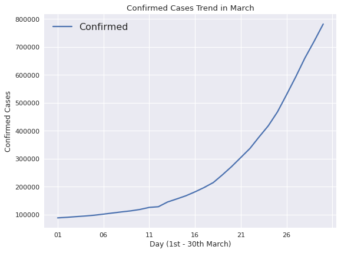

```python
march_data.groupby('Day')[['Confirmed']].sum().plot()

plt.title('Confirmed Cases Trend in March')
plt.xlabel('Day (1st - 30th March)')
plt.ylabel('Confirmed Cases')
plt.legend();
```

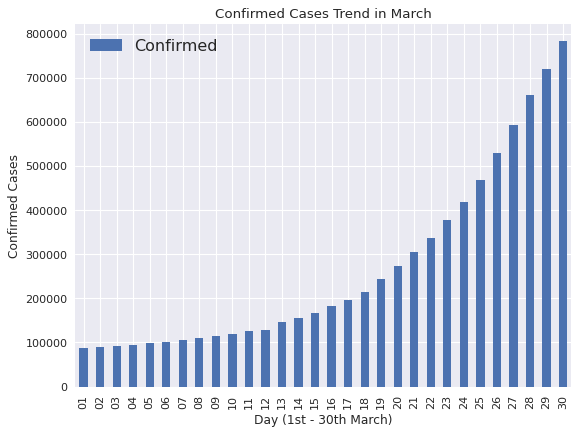

```python
march_data.groupby('Day')[['Confirmed']].sum().plot.bar()

plt.title('Confirmed Cases Trend in March')
plt.xlabel('Day (1st - 30th March)')
plt.ylabel('Confirmed Cases')
plt.legend();
```

**Question. What is the Confirmed cases trend of top 5 countries(by confirmed cases) in March month?**

```python
top5_countries = march_data[march_data['Day'] == march_data['Day'].max()]\
        .groupby('Country')[['Confirmed']]\
        .sum()\
        .nlargest(5, 'Confirmed')\
        .index.values
```

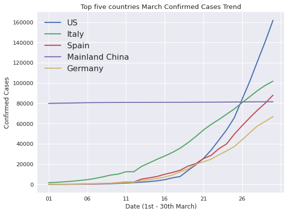

```python
for country in top5_countries:
    march_data[march_data['Country'] == country][['Day', 'Confirmed']]\
        .groupby('Day')\
        .sum()['Confirmed']\
        .plot(label=country)

plt.title('Top five countries March Confirmed Cases Trend')
plt.xlabel('Date (1st - 30th March)')
plt.ylabel('Confirmed Cases')
plt.legend(loc='middle');
```

**Questions. What is the distribution of Confirmed, Deaths & Recovered cases out of total cases for top 5 countries(by Confirmed cases) in the month of Month?**

```python
top5_countries_grouped_data = march_data[
    march_data['Day'] == march_data['Day'].max()]\
    .groupby('Country')[['Confirmed', 'Deaths', 'Recovered']]\
    .sum()\
    .nlargest(5, 'Confirmed')
```

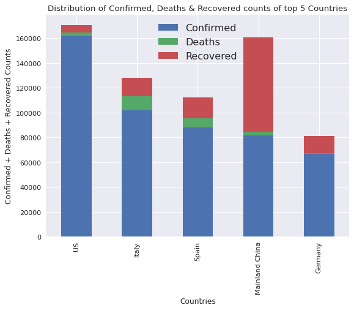

```python
top5_countries_grouped_data.plot.bar(stacked=True)

plt.title('Distribution of Confirmed, Deaths & Recovered counts of top 5 Countries')
plt.xlabel('Countries')
plt.ylabel('Confirmed + Deaths + Recovered Counts')
plt.legend(loc='best');
```

### Homework

- [Google Form Link](https://forms.gle/SUxrqz8LbHV6vUva9)

**Question 1. How many states have been infected in China?**

**Question 2. Name the 3rd most infected state in the US?**

**Question 3. Out of China, US, Italy and Spain which country took the minimum number of days to reach 80k Confirmed cases from 10k Confirmed cases? Also, find out the minimum number of days?**

**Question 4. On which date, the maximum number of confirmed cases was reported by a single country? Also, name the country.**

**Question 5. Is there any day where number of deaths reported by a country was more than number of confirmed cases on the same day? If yes, find out the day & country.**

### Resources

- [Jupyter Cheat Sheet](https://datacamp-community-prod.s3.amazonaws.com/48093c40-5303-45f4-bbf9-0c96c0133c40)
- [10 Minutes to Pandas](https://pandas.pydata.org/pandas-docs/version/0.23.4/10min.html)
- [Pandas Cheat Sheet](https://pandas.pydata.org/Pandas_Cheat_Sheet.pdf)
- [Pandas comparision wih SQL](https://pandas.pydata.org/docs/getting_started/comparison/comparison_with_sql.html)
- [Visualisation using Pandas](https://pandas.pydata.org/pandas-docs/version/0.23.4/visualization.html)
- [Seaborn: For better visualisations](https://seaborn.pydata.org/tutorial.html)
- [Kaggle Notebooks Sorted by Most Votes](https://www.kaggle.com/sudalairajkumar/novel-corona-virus-2019-dataset/kernels?sortBy=voteCount&group=everyone&pageSize=20&datasetId=494724)